# Predicción de Cancer de mama

### Objetivo

Usaremos un flujo de trabajo de machine learning para diagnosticar el cáncer como benigno (no se expande al resto del cuerpo) o maligno (se expande al resto del cuerpo). La idea es proporcionar un detección temprana del cancer para evitar su expansión

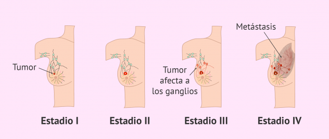

## Preparar entorno de trabajo

### Crear entorno virtual (Conda/Python env)

Una vez creado el entorno lo activamos con `conda activate myenv` para instalar las librerías necesarias

### Instalamos las librerías necesarias

Para instalar las librerías podemos hacerlo mediante `pip install` o `conda install`

```python
import numpy as np
import pandas as pd
import matplotlib.pyplot as plt
import seaborn as sns
import warnings
warnings.filterwarnings("ignore")
warnings.simplefilter(action='ignore', category=FutureWarning)
%matplotlib inline
%config InlineBackend.figure_formats = ['svg']
plt.rcParams['svg.fonttype'] = 'none'
```

## Paso 1: Adquisición de los datos

```python
from sklearn.datasets import load_breast_cancer
breast_cancer = load_breast_cancer()
```

```python
# Observación de variables target
print(breast_cancer.target_names)
```

```
['malignant' 'benign']
```

```python
# El resto de variables
print(breast_cancer.feature_names)
print()
print("Serían un total de: ",len(breast_cancer.feature_names))
```

```
['mean radius' 'mean texture' 'mean perimeter' 'mean area'
 'mean smoothness' 'mean compactness' 'mean concavity'
 'mean concave points' 'mean symmetry' 'mean fractal dimension'
 'radius error' 'texture error' 'perimeter error' 'area error'
 'smoothness error' 'compactness error' 'concavity error'
 'concave points error' 'symmetry error' 'fractal dimension error'
 'worst radius' 'worst texture' 'worst perimeter' 'worst area'
 'worst smoothness' 'worst compactness' 'worst concavity'
 'worst concave points' 'worst symmetry' 'worst fractal dimension']

Serían un total de:  30
```

### Lectura de los datos

Crearemos un dataframe y lo rellenaremos con cada una de las "features" del dataset

```python
# Cargamos los datos en un dataframe
df_features = pd.DataFrame(breast_cancer.data, columns = breast_cancer.feature_names)
```

```python
df_features.head()
```

|  | mean radius | mean texture | mean perimeter | mean area | mean smoothness | mean compactness | mean concavity | mean concave points | mean symmetry | mean fractal dimension | ... | worst radius | worst texture | worst perimeter | worst area | worst smoothness | worst compactness | worst concavity | worst concave points | worst symmetry | worst fractal dimension |
| --- | --- | --- | --- | --- | --- | --- | --- | --- | --- | --- | --- | --- | --- | --- | --- | --- | --- | --- | --- | --- | --- |
| 0 | 17.99 | 10.38 | 122.80 | 1001.0 | 0.11840 | 0.27760 | 0.3001 | 0.14710 | 0.2419 | 0.07871 | ... | 25.38 | 17.33 | 184.60 | 2019.0 | 0.1622 | 0.6656 | 0.7119 | 0.2654 | 0.4601 | 0.11890 |
| 1 | 20.57 | 17.77 | 132.90 | 1326.0 | 0.08474 | 0.07864 | 0.0869 | 0.07017 | 0.1812 | 0.05667 | ... | 24.99 | 23.41 | 158.80 | 1956.0 | 0.1238 | 0.1866 | 0.2416 | 0.1860 | 0.2750 | 0.08902 |
| 2 | 19.69 | 21.25 | 130.00 | 1203.0 | 0.10960 | 0.15990 | 0.1974 | 0.12790 | 0.2069 | 0.05999 | ... | 23.57 | 25.53 | 152.50 | 1709.0 | 0.1444 | 0.4245 | 0.4504 | 0.2430 | 0.3613 | 0.08758 |
| 3 | 11.42 | 20.38 | 77.58 | 386.1 | 0.14250 | 0.28390 | 0.2414 | 0.10520 | 0.2597 | 0.09744 | ... | 14.91 | 26.50 | 98.87 | 567.7 | 0.2098 | 0.8663 | 0.6869 | 0.2575 | 0.6638 | 0.17300 |
| 4 | 20.29 | 14.34 | 135.10 | 1297.0 | 0.10030 | 0.13280 | 0.1980 | 0.10430 | 0.1809 | 0.05883 | ... | 22.54 | 16.67 | 152.20 | 1575.0 | 0.1374 | 0.2050 | 0.4000 | 0.1625 | 0.2364 | 0.07678 |

5 rows × 30 columns

### Lectura de la variable "target"

```python
# 1 - Benigno
# 0 - Maligno
df_target = pd.DataFrame(breast_cancer.target, columns=['target'])
# df_target.head()
```

```python
df_target['target'].value_counts()
```

```
target
1    357
0    212
Name: count, dtype: int64
```

Según la descripción del conjunto de datos, la distribución de la variable objetivo es: `212 - Maligno`, `357 - Benigno`

Para empezar a trabajar concatenamos ambos dataframes: características (Features) y variable objetivo (target)

```python
df = pd.concat([df_features, df_target], axis=1)
df.head()
# Ya tiene df la variable objetivo al final
```

|  | mean radius | mean texture | mean perimeter | mean area | mean smoothness | mean compactness | mean concavity | mean concave points | mean symmetry | mean fractal dimension | ... | worst texture | worst perimeter | worst area | worst smoothness | worst compactness | worst concavity | worst concave points | worst symmetry | worst fractal dimension | target |
| --- | --- | --- | --- | --- | --- | --- | --- | --- | --- | --- | --- | --- | --- | --- | --- | --- | --- | --- | --- | --- | --- |
| 0 | 17.99 | 10.38 | 122.80 | 1001.0 | 0.11840 | 0.27760 | 0.3001 | 0.14710 | 0.2419 | 0.07871 | ... | 17.33 | 184.60 | 2019.0 | 0.1622 | 0.6656 | 0.7119 | 0.2654 | 0.4601 | 0.11890 | 0 |
| 1 | 20.57 | 17.77 | 132.90 | 1326.0 | 0.08474 | 0.07864 | 0.0869 | 0.07017 | 0.1812 | 0.05667 | ... | 23.41 | 158.80 | 1956.0 | 0.1238 | 0.1866 | 0.2416 | 0.1860 | 0.2750 | 0.08902 | 0 |
| 2 | 19.69 | 21.25 | 130.00 | 1203.0 | 0.10960 | 0.15990 | 0.1974 | 0.12790 | 0.2069 | 0.05999 | ... | 25.53 | 152.50 | 1709.0 | 0.1444 | 0.4245 | 0.4504 | 0.2430 | 0.3613 | 0.08758 | 0 |
| 3 | 11.42 | 20.38 | 77.58 | 386.1 | 0.14250 | 0.28390 | 0.2414 | 0.10520 | 0.2597 | 0.09744 | ... | 26.50 | 98.87 | 567.7 | 0.2098 | 0.8663 | 0.6869 | 0.2575 | 0.6638 | 0.17300 | 0 |
| 4 | 20.29 | 14.34 | 135.10 | 1297.0 | 0.10030 | 0.13280 | 0.1980 | 0.10430 | 0.1809 | 0.05883 | ... | 16.67 | 152.20 | 1575.0 | 0.1374 | 0.2050 | 0.4000 | 0.1625 | 0.2364 | 0.07678 | 0 |

5 rows × 31 columns

## Paso 2: Preprocesamiento de los datos

Comprobamos si los datos necesitan ser pre-procesados.

```python
df.isna().sum()
```

```
mean radius                0
mean texture               0
mean perimeter             0
mean area                  0
mean smoothness            0
mean compactness           0
mean concavity             0
mean concave points        0
mean symmetry              0
mean fractal dimension     0
radius error               0
texture error              0
perimeter error            0
area error                 0
smoothness error           0
compactness error          0
concavity error            0
concave points error       0
symmetry error             0
fractal dimension error    0
worst radius               0
worst texture              0
worst perimeter            0
worst area                 0
worst smoothness           0
worst compactness          0
worst concavity            0
worst concave points       0
worst symmetry             0
worst fractal dimension    0
target                     0
dtype: int64
```

Los datos han sido limpiados y pre-procesados previamente

### Escalar los datos

Muchos algoritmos de aprendizaje automático funcionan mejor cuando las características están en una escala relativamente similar y cerca de la distribución normal. **MinMaxScaler, RobustScaler, StandardScaler y Normalizer** son métodos scikit-learn para preprocesar datos para el aprendizaje automático. El método que necesita, si corresponde, depende de su tipo de modelo y los valores de sus características.

```python
from sklearn.preprocessing import StandardScaler
scaler=StandardScaler()
y = df['target'] #Asignamos la variable target
X = df.drop(['target'], axis=1) # quito la variable dependiente "Y"
scaler.fit(X) # calculo la media para poder hacer la transformacion
X_scaled=scaler.transform(X)# Ahora si, escalo los datos y los normalizo
```

```python
X.shape
```

```
(569, 30)
```

## Paso 3: PCA (Principal Component Analysis)

Otra forma de mejorar nuestro modelo es usando la reducción de dimensión, podemos aproximar el conjunto de datos original con menos variables, mientras reducimos el poder computacional para ejecutar nuestro modelo. Usando PCA, podemos estudiar la razón de varianza explicada acumulativa de estas características para comprender qué características explican la mayor varianza en los datos.

#### Ajuste del número de componentes

```python
import matplotlib.pyplot as plt
import seaborn as sns
from sklearn.decomposition import PCA

plt.figure(figsize=(10, 5))

pca_all = PCA(n_components=30)
pca_transform = pca_all.fit_transform(X_scaled)

sns.set(style='whitegrid')
plt.plot(np.cumsum(pca_all.explained_variance_ratio_))
plt.xlabel('number of components')
plt.ylabel('cumulative explained variance')
plt.axvline(linewidth=4, color='r', linestyle = '--', x=23, ymin=0, ymax=1)
plt.show()

evr = pca_all.explained_variance_ratio_
cvr = np.cumsum(pca_all.explained_variance_ratio_)
pca_df = pd.DataFrame()
pca_df['Cumulative Variance Ratio'] = cvr
pca_df['Explained Variance Ratio'] = evr
display(pca_df.head(10))
```

[figure not shown]

|  | Cumulative Variance Ratio | Explained Variance Ratio |
| --- | --- | --- |
| 0 | 0.442720 | 0.442720 |
| 1 | 0.632432 | 0.189712 |
| 2 | 0.726364 | 0.093932 |
| 3 | 0.792385 | 0.066021 |
| 4 | 0.847343 | 0.054958 |
| 5 | 0.887588 | 0.040245 |
| 6 | 0.910095 | 0.022507 |
| 7 | 0.925983 | 0.015887 |
| 8 | 0.939879 | 0.013896 |
| 9 | 0.951569 | 0.011690 |

```python
pca_dims = []
for x in range(0, len(pca_df)):
    pca_dims.append('PCA Component {}'.format(x))
pca_test_df = pd.DataFrame(pca_all.components_, columns=X.columns, index=pca_dims)
```

## PCA

```python
pca = PCA(n_components=15)
X_pca = pca.fit_transform(X_scaled)
X_pca.shape
```

```
(569, 15)
```

## Paso 4: Predicciones

### K Neighbors Classifier

Ahora particionaremos el dataset en `training` y `test`

```python
from sklearn.model_selection import train_test_split

#dividimos en sets de entrenamiento y test
X_train, X_test, y_train, y_test = train_test_split(X_pca, y, train_size=0.7,random_state=42)
```

> Tras hacer el split en el conjunto de entrenamiento y de test, tenemos que tener en cuenta que el conjunto de entrenamiento ha cambiado, ya que hemos realizado las siguientes modificaciones:  
> • Estandarización de los datos  
> • PCA (components = 15)

Definimos función para mostrar los resultados

```python
from sklearn.metrics import confusion_matrix

def mostrar_resultados(y_test, pred_y):
    conf_matrix = confusion_matrix(y_test, pred_y)
    plt.figure(figsize=(3, 3))
    sns.heatmap(conf_matrix, xticklabels=["Malignant","Benign"], yticklabels=["Malignant","Benign"], annot=True, fmt="d", cmap="Blues", cbar=False);
    plt.title("Confusion matrix")
    plt.ylabel('True class')
    plt.xlabel('Predicted class')
    plt.show()
```

Entrenamos el modelo

```python
from sklearn.neighbors import KNeighborsClassifier
neigh = KNeighborsClassifier(n_neighbors=3)
neigh.fit(X_train, y_train)

# Predección en el conjunto de test
y_pred = neigh.predict(X_test)
```

##### Evaluación del modelo

```python
# Realizamos predicciones en el conjunto de Test
pred_y = neigh.predict(X_test)
mostrar_resultados(y_test, pred_y)

print('Precisión en el set de Entrenamiento: {:.2f}'.format(neigh.score(X_train, y_train)))
print('Precisión en el set de Test: {:.2f}'.format(neigh.score(X_test, y_test)))
```

[figure not shown]

```
Precisión en el set de Entrenamiento: 0.99
Precisión en el set de Test: 0.96
```